# NFL Big Data Bowl 2025: Pre-snap to Post-snap Predictions

Yash Gupta

November 4, 2024

# Introduction

## The NFL Big Data Bowl 2025 focuses on pre-snap to post-snap predictions. With 40 seconds between plays, teams make crucial decisions involving personnel, formations, and strategic movements. This analysis aims to uncover patterns in pre-snap behavior that can predict post-snap actions.

## Data Preparation

```r
pla <- full_join(player_plays, plays, by = c("gameId", "playId"))

snap <- tibble(
  linesetmotion = pla$motionSinceLineset,
  ballsnapmotion = pla$inMotionAtBallSnap,
  shiftSinceLineset = pla$shiftSinceLineset,
  passResult = pla$passResult,
  hadRushAttempt = pla$hadRushAttempt,
  hadDropback = pla$hadDropback,
  game = pla$gameId,
  nfl = pla$nflId,
  play = pla$playId,
  desc = pla$playDescription,
  formation = pla$offenseFormation,
  yards = pla$yardsGained,
  clock = pla$playClockAtSnap,
  yardsToGo = pla$yardsToGo,
  pressure = pla$unblockedPressure,
  manZone = pla$pff_manZone,
  coverage = pla$pff_passCoverage,
  run = pla$pff_runConceptPrimary
)

snap_unique <- snap %>%
  distinct(desc, .keep_all = TRUE) %>%
  mutate(play_type = ifelse(is.na(passResult), "Rush", "Pass")) %>%
  filter(!is.na(formation) & formation != "NA")
```

# Play Type Prediction

## Play Type by Yards to Go and Formation

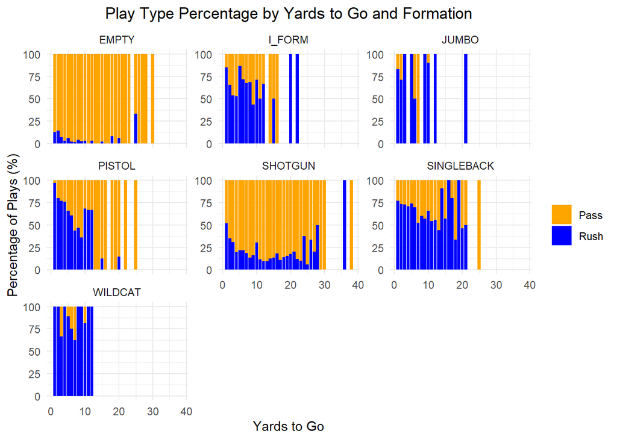

```r
play_summary <- snap_unique %>%
  group_by(yardsToGo, play_type, formation) %>%
  summarise(play_count = n(), .groups = 'drop') %>%
  group_by(yardsToGo, formation) %>%
  mutate(percentage = play_count / sum(play_count) * 100)

ggplot(play_summary, aes(x = yardsToGo, y = percentage, fill = play_type)) +
  geom_bar(stat = "identity", position = "stack") +
  facet_wrap(~ formation, scales = "free_y") +
  labs(title = "Play Type Percentage by Yards to Go and Formation",
       x = "Yards to Go", y = "Percentage of Plays (%)") +
  scale_fill_manual(values = c("Rush" = "blue", "Pass" = "orange")) +
  theme_minimal() +
  theme(plot.title = element_text(hjust = 0.5),
        legend.title = element_blank())
```

## This visualization reveals how play type (Rush vs Pass) varies based on yards to go and offensive formation. We can observe that:

### Some formations, like “SHOTGUN”, have a higher percentage of pass plays regardless of yards to go.

### Formations like “I_FORM” tend to have a higher percentage of rush plays, especially in short-yardage situations.

### These insights can be valuable for defensive coordinators in predicting play types based on pre-snap formations and game situations.

# Scheme Prediction

## Coverage Types by Formation

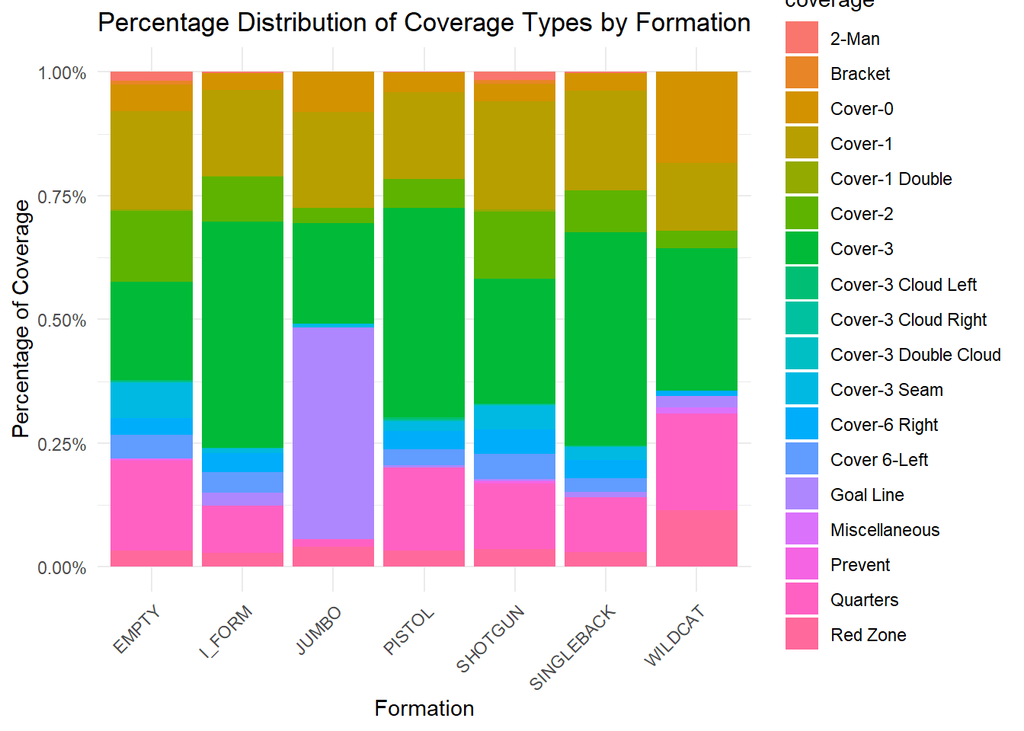

```r
coverage_data <- snap_unique %>%
  drop_na(formation, coverage) %>%
  group_by(formation, coverage) %>%
  summarise(count = n(), .groups = 'drop') %>%
  group_by(formation) %>%
  mutate(percentage = (count / sum(count)) * 100)

ggplot(coverage_data, aes(x = formation, y = percentage, fill = coverage)) +
  geom_bar(stat = "identity", position = "fill") +
  labs(title = "Percentage Distribution of Coverage Types by Formation",
       x = "Formation", y = "Percentage of Coverage") +
  scale_y_continuous(labels = scales::percent_format(scale = 1)) +
  theme_minimal() +
  theme(axis.text.x = element_text(angle = 45, hjust = 1))
```

## This chart illustrates the distribution of defensive coverage types for each offensive formation. It can help predict likely defensive schemes based on the offensive setup.

# Player Prediction

## Yards Gained Distribution by Formation and Coverage

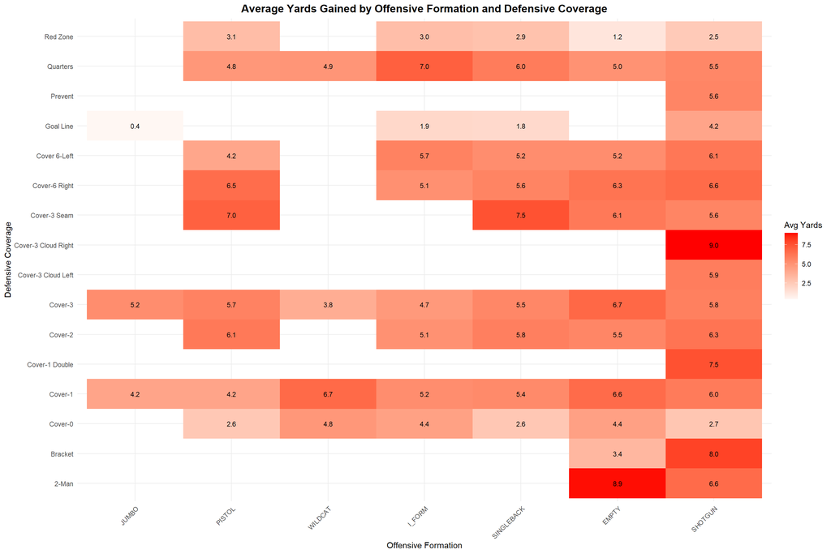

```r
library(ggplot2)
library(dplyr)
library(forcats)

# Prepare the data
plot_data <- snap_unique %>%
  filter(!is.na(formation) & !is.na(coverage) & !is.na(yards)) %>%
  group_by(formation, coverage) %>%
  summarise(
    avg_yards = mean(yards, na.rm = TRUE),
    n = n(),
    .groups = 'drop'
  ) %>%
  filter(n > 10)  # Filter out combinations with few occurrences

# Create the plot
ggplot(plot_data, aes(x = fct_reorder(formation, avg_yards), y = coverage, fill = avg_yards)) +
  geom_tile() +
  geom_text(aes(label = sprintf("%.1f", avg_yards)), color = "black", size = 3) +
  scale_fill_gradient2(low = "blue", mid = "white", high = "red", midpoint = 0) +
  labs(
    title = "Average Yards Gained by Offensive Formation and Defensive Coverage",
    x = "Offensive Formation",
    y = "Defensive Coverage",
    fill = "Avg Yards"
  ) +
  theme_minimal() +
  theme(
    axis.text.x = element_text(angle = 45, hjust = 1),
    plot.title = element_text(hjust = 0.5, size = 14, face = "bold"),
    legend.position = "right"
  )
```

## This plot shows the distribution of yards gained for different formation-coverage pairings. It can help predict player performance and potential play outcomes based on pre-snap alignments.

# Pre-snap Motion Analysis

```r
motion_summary <- snap_unique %>%
  group_by(formation) %>%
  summarise(
    pass_attempts = sum(passResult != "NA", na.rm = TRUE),
    rush_attempts = sum(is.na(passResult)),
    total_plays = n(),
    average_yards = mean(yards, na.rm = TRUE)
  ) %>%
  mutate(
    pass_prob = pass_attempts / total_plays,
    rush_prob = rush_attempts / total_plays
  )

print(motion_summary)
```

```
## # A tibble: 7 × 7
##   formation  pass_attempts rush_attempts total_plays average_yards pass_prob
##   <chr>              <int>         <int>       <int>         <dbl>     <dbl>
## 1 EMPTY               1295            47        1342          5.78     0.965
## 2 I_FORM               299           736        1035          5.00     0.289
## 3 JUMBO                 21           104         125          2.33     0.168
## 4 PISTOL               226           415         641          5.04     0.353
## 5 SHOTGUN             6551          2238        8789          5.74     0.745
## 6 SINGLEBACK          1306          2609        3915          5.35     0.334
## 7 WILDCAT               13            74          87          4.64     0.149
## # ℹ 1 more variable: rush_prob <dbl>
```

# Formation Effectiveness

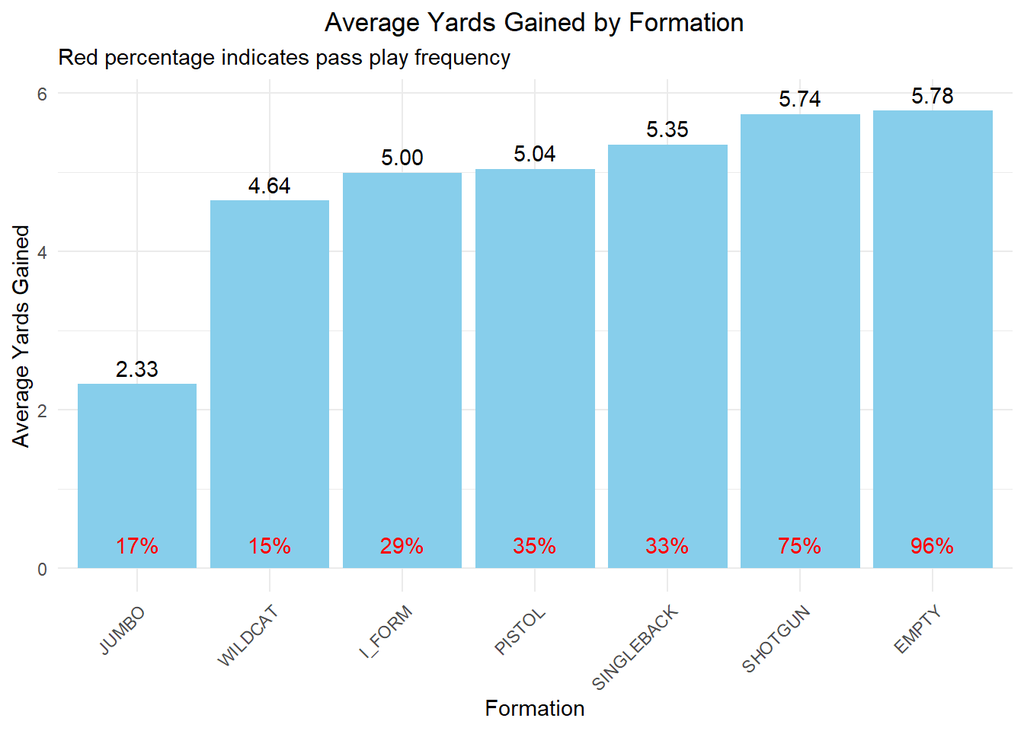

```r
formation_summary <- snap_unique %>%
  group_by(formation) %>%
  summarise(
    avg_yards = mean(yards, na.rm = TRUE),
    play_count = n(),
    pass_percentage = mean(play_type == "Pass") * 100,
    .groups = 'drop'
  ) %>%
  arrange(desc(avg_yards))

ggplot(formation_summary, aes(x = reorder(formation, avg_yards), y = avg_yards)) +
  geom_bar(stat = "identity", fill = "skyblue") +
  geom_text(aes(label = sprintf("%.2f", avg_yards), y = avg_yards + 0.1), vjust = 0) +
  geom_text(aes(label = sprintf("%.0f%%", pass_percentage), y = 0.2), vjust = 0, color = "red") +
  labs(title = "Average Yards Gained by Formation",
       subtitle = "Red percentage indicates pass play frequency",
       x = "Formation", y = "Average Yards Gained") +
  theme_minimal() +
  theme(plot.title = element_text(hjust = 0.5),
        axis.text.x = element_text(angle = 45, hjust = 1))
```

```r
print(formation_summary)
```

```
## # A tibble: 7 × 4
##   formation  avg_yards play_count pass_percentage
##   <chr>          <dbl>      <int>           <dbl>
## 1 EMPTY           5.78       1342            96.5
## 2 SHOTGUN         5.74       8789            74.5
## 3 SINGLEBACK      5.35       3915            33.4
## 4 PISTOL          5.04        641            35.3
## 5 I_FORM          5.00       1035            28.9
## 6 WILDCAT         4.64         87            14.9
## 7 JUMBO           2.33        125            16.8
```

## This chart provides insights into the effectiveness of different formations:

### Formations like “EMPTY” and “SHOTGUN” tend to gain more yards on average.

### These formations also have a higher percentage of pass plays (as indicated by the red percentages).

### Some formations with lower average yards (e.g., “I_FORM”) tend to have a lower percentage of pass plays.

### This analysis can help offensive coordinators choose formations based on their desired play type and yardage goals, while also informing defensive strategies against specific formations.

# Conclusion

### These insights can be valuable for both offensive and defensive strategy in the NFL, allowing teams to better anticipate and counter their opponents’ actions.